# Portland Crime Forecasting with XGBoost

- Show All Code
- Hide All Code

Data Science Portfolio

Author

Tucker Trost

## Elevator pitch

*This project involves cleaning, exploring, and modeling crime data from Portland, Oregon (2015–2023). After addressing missing data and reducing noise, we uncovered key trends in offense types, report times, and their relationship to neighborhood, day, and time. We then developed an XGBoost machine learning model that predicts daily total offense counts by neighborhood, currently achieving an R² score of 0.62. This model could support better resource planning and crime prevention strategies across the city.*

### Data Source

*The dateset that I am using was accessed directly from [Portland Police Bureau’s Open Data initiative](https://www.portland.gov/police/open-data/crime-statistics); compiled from 2015-2023. This dataset is being used under this [license](https://creativecommons.org/publicdomain/zero/1.0/).*

### Data Dictionary

**Address:** Address of reported incident at the 100 block level (e.g.: 1111 SW 2nd Ave would be 1100 Block SW 2nd Ave).

**Case Number:** The case year and number for the reported incident (YY-######).

**Crime Against:** Crime against category (Person, Property, or Society).

**Neighborhood:** Neighborhood where incident occurred. If the neighborhood name is missing, the incident occurred outside of the boundaries of the Portland neighborhoods or at a location that could not be assigned to a specific address in the system. (e.g., Portland, near Washington Park, on the streetcar, etc.).

**Occur Date:** Date the incident occurred. The exact occur date is sometimes unknown. In most situations, the first possible date the crime could have occurred is used as the occur date. (For example, victims return home from a week-long vacation to find their home burglarized. The burglary could have occurred at any point during the week. The first date of their vacation would be listed as the occur date.)

**Occur Time**: Time the incident occurred. The exact occur time is sometimes unknown. In most situations, the first possible time the crime could have occurred is used as the occur time. The time is reported in the 24-hour clock format, with the first two digits representing hour (ranges from 00 to 23) and the second two digits representing minutes (ranges from 00 to 59).

**Offense Category:** Category of offense (for example, Assault Offenses).

**Offense Type:** Type of offense (for example, Aggravated Assault)Note: The statistic for Homicide Offenses has been updated in the Group A Crimes report to align with the 2019 FBI NIBRS definitions. The statistic for Homicide Offenses includes (09A) Murder & Non-negligent Manslaughter and (09B) Negligent Manslaughter. As of January 1, 2019, the FBI expanded the definition of negligent manslaughter to include traffic fatalities that result in an arrest for driving under the influence, distracted driving, or reckless driving. **The change in definition impacts the 2019 homicide offenses statistic and the comparability of 2019 homicide statistics to prior year.**

**Open Data Lat/Lon:** Generalized Latitude / Longitude of the reported incident. For offenses that occurred at a specific address, the point is mapped to the block’s midpoint. Offenses that occurred at an intersection is mapped to the intersection centroid.

**Open Data X/Y:** Generalized XY point of the reported incident. For offenses that occurred at a specific address, the point is mapped to the block’s midpoint. Offenses that occurred at an intersection is mapped to the intersection centroid. To protect the identity of victims and other privacy concerns, the points of certain case types are not released. XY points use the Oregon State Plane North (3601), NAD83 HARN, US International Feet coordinate system.

**Offense Count:** Number of offenses per incident. Offenses (i.e. this field) are summed for counting purposes.

## Prepare

**Read and format project data**

```python
# Load in Data
pcrime_15 = pd.read_csv('CrimeData-2015.csv')
pcrime_16 = pd.read_csv('CrimeData-2016.csv')
pcrime_17 = pd.read_csv('CrimeData-2017.csv')
pcrime_18 = pd.read_csv('CrimeData-2018.csv')
pcrime_19 = pd.read_csv('CrimeData-2019.csv')
pcrime_20 = pd.read_csv('CrimeData-2020.csv')
pcrime_21 = pd.read_csv('CrimeData-2021.csv')
pcrime_22 = pd.read_csv('CrimeData-2022.csv')
pcrime_23 = pd.read_csv('CrimeData-2023.csv')

# Combine Datasets
pcrime_combined = pd.concat([pcrime_15,pcrime_16,pcrime_17,pcrime_18,pcrime_19,pcrime_20,pcrime_21,pcrime_22,pcrime_23], ignore_index=True)
pcrime_combined.head()
```

|  | Address | CaseNumber | CrimeAgainst | Neighborhood | OccurDate | OccurTime | OffenseCategory | OffenseType | OpenDataLat | OpenDataLon | OpenDataX | OpenDataY | ReportDate | OffenseCount |
| --- | --- | --- | --- | --- | --- | --- | --- | --- | --- | --- | --- | --- | --- | --- |
| 0 | NaN | 15-X197430 | Person | Piedmont | 5/12/2015 | 1400 | Assault Offenses | Intimidation | NaN | NaN | NaN | NaN | 5/12/2015 | 1 |
| 1 | NaN | 15-X4282999 | Person | Buckman West | 5/1/2015 | 2143 | Assault Offenses | Simple Assault | NaN | NaN | NaN | NaN | 5/1/2015 | 1 |
| 2 | NaN | 15-X4283033 | Person | University Park | 5/1/2015 | 1625 | Assault Offenses | Simple Assault | NaN | NaN | NaN | NaN | 5/1/2015 | 1 |
| 3 | NaN | 15-X4283218 | Person | Madison South | 5/1/2015 | 1820 | Assault Offenses | Simple Assault | NaN | NaN | NaN | NaN | 5/1/2015 | 1 |
| 4 | NaN | 15-X4283218 | Person | Madison South | 5/1/2015 | 1820 | Kidnapping/Abduction | Kidnapping/Abduction | NaN | NaN | NaN | NaN | 5/1/2015 | 1 |

### What is our goal?

*Thinking forward to the analysis that I want to perform with this data, I need to understand what I am looking for when it comes to cleaning. I know that I want to focus my analysis on the temporal crime trends across the various neighborhoods of Portland. Based on this understanding, I get a better sense of what aspects of the data need to be cleaned.*

**Identify Missing Data**

```python
pcrime_combined.isna().sum()
```

```
Address            44998
CaseNumber             0
CrimeAgainst           0
Neighborhood       17566
OccurDate              0
OccurTime              0
OffenseCategory        0
OffenseType            0
OpenDataLat        56511
OpenDataLon        56511
OpenDataX          56511
OpenDataY          56511
ReportDate             0
OffenseCount           0
dtype: int64
```

### Initial Observations

1. *A time to report column would be useful*
   - *Convert OccurDate and ReportDate to datetime*
   - *Create a time to report column*
2. *OpenDataX/Y don’t seem necessary for our analysis*
   - *Drop OpenDataX and OpenDataY columns*
3. *Address column seems to be redundant as most entries are just a general location*
   - *Drop Address column*
4. *Neighborhood averages can be used to find lat/lon*
   - *Drop rows with missing Neighborhood and OpenDataLat*
   - *Replace all rows with neighborhood but missing Lat/Lon data with average Lat/Lon of their neighborhood*

## Data Cleaning

**Cleaning**

```python
# Calculate average Lat/Lon for each neighborhood
neighborhood_means = pcrime_combined.groupby('Neighborhood')[['OpenDataLat','OpenDataLon']].transform('mean')

# Clean the data
pcrime_cleaned = (
    pcrime_combined
    .drop(columns=['Address', 'OpenDataX', 'OpenDataY'])  # Drop X/Y
    .dropna(subset=['OpenDataLat', 'Neighborhood'], how='all')  # Drop missing lat/lon and Neighborhoods
    .assign(
        OccurDate=pd.to_datetime(pcrime_combined['OccurDate']),  # Convert dates to datetime
        week=lambda x: x.OccurDate.dt.isocalendar().week,
        year=lambda x: x.OccurDate.dt.year,
        month=lambda x: x.OccurDate.dt.month,
        dayofmonth=lambda x: x.OccurDate.dt.day,
        ReportDate=pd.to_datetime(pcrime_combined['ReportDate']),
        ReportDiff=lambda x: (x['ReportDate'] - x['OccurDate']).dt.days,  # Calculate time to report
        OpenDataLat=lambda x: x['OpenDataLat'].fillna(neighborhood_means['OpenDataLat']),  # Fill missing Lat/Lon with average Lat/Lon of given neighborhood
        OpenDataLon=lambda x: x['OpenDataLon'].fillna(neighborhood_means['OpenDataLon']),
        OccurTime=lambda x: x['OccurTime'].astype(str).str.zfill(4),  # Ensure time is in HHMM format
        OccurDateTime=lambda x: pd.to_datetime(
            x['OccurDate'].dt.strftime('%Y-%m-%d') + ' ' +
            x['OccurTime'].str[:2] + ':' + x['OccurTime'].str[2:]), # Combine date and formatted time into datetime
        OccurHour=lambda x: x.OccurDateTime.dt.hour,
    )
    .loc[lambda x: x['OccurDateTime'].dt.year.between(2015, 2023)]  # Filter rows with years within 2015–2023
)

pcrime_cleaned
```

|  | CaseNumber | CrimeAgainst | Neighborhood | OccurDate | OccurTime | OffenseCategory | OffenseType | OpenDataLat | OpenDataLon | ReportDate | OffenseCount | week | year | month | dayofmonth | ReportDiff | OccurDateTime | OccurHour |
| --- | --- | --- | --- | --- | --- | --- | --- | --- | --- | --- | --- | --- | --- | --- | --- | --- | --- | --- |
| 0 | 15-X197430 | Person | Piedmont | 2015-05-12 | 1400 | Assault Offenses | Intimidation | 45.575321 | -122.669950 | 2015-05-12 | 1 | 20 | 2015 | 5 | 12 | 0 | 2015-05-12 14:00:00 | 14 |
| 1 | 15-X4282999 | Person | Buckman West | 2015-05-01 | 2143 | Assault Offenses | Simple Assault | 45.517973 | -122.659334 | 2015-05-01 | 1 | 18 | 2015 | 5 | 1 | 0 | 2015-05-01 21:43:00 | 21 |
| 2 | 15-X4283033 | Person | University Park | 2015-05-01 | 1625 | Assault Offenses | Simple Assault | 45.580393 | -122.727295 | 2015-05-01 | 1 | 18 | 2015 | 5 | 1 | 0 | 2015-05-01 16:25:00 | 16 |
| 3 | 15-X4283218 | Person | Madison South | 2015-05-01 | 1820 | Assault Offenses | Simple Assault | 45.540839 | -122.578812 | 2015-05-01 | 1 | 18 | 2015 | 5 | 1 | 0 | 2015-05-01 18:20:00 | 18 |
| 4 | 15-X4283218 | Person | Madison South | 2015-05-01 | 1820 | Kidnapping/Abduction | Kidnapping/Abduction | 45.540839 | -122.578812 | 2015-05-01 | 1 | 18 | 2015 | 5 | 1 | 0 | 2015-05-01 18:20:00 | 18 |
| ... | ... | ... | ... | ... | ... | ... | ... | ... | ... | ... | ... | ... | ... | ... | ... | ... | ... | ... |
| 531881 | 23-225440 | Society | Sylvan-Highlands | 2023-08-27 | 1420 | Weapon Law Violations | Weapons Law Violations | 45.508945 | -122.731195 | 2023-08-27 | 1 | 34 | 2023 | 8 | 27 | 0 | 2023-08-27 14:20:00 | 14 |
| 531882 | 23-51637 | Property | Arlington Heights | 2023-02-23 | 0330 | Motor Vehicle Theft | Motor Vehicle Theft | 45.506744 | -122.713355 | 2023-02-25 | 1 | 8 | 2023 | 2 | 23 | 2 | 2023-02-23 03:30:00 | 3 |
| 531883 | 23-227984 | Person | Goose Hollow | 2023-08-30 | 0920 | Assault Offenses | Aggravated Assault | 45.515555 | -122.693709 | 2023-08-30 | 1 | 35 | 2023 | 8 | 30 | 0 | 2023-08-30 09:20:00 | 9 |
| 531884 | 23-40689 | Property | Forest Park | 2023-02-13 | 1130 | Motor Vehicle Theft | Motor Vehicle Theft | 45.540437 | -122.736728 | 2023-02-13 | 1 | 7 | 2023 | 2 | 13 | 0 | 2023-02-13 11:30:00 | 11 |
| 531885 | 23-137815 | Property | Forest Park | 2023-05-23 | 1300 | Larceny Offenses | Theft From Motor Vehicle | 45.540437 | -122.736728 | 2023-05-26 | 1 | 21 | 2023 | 5 | 23 | 3 | 2023-05-23 13:00:00 | 13 |

521247 rows × 18 columns

```python
pcrime_cleaned.info()
```

```
<class 'pandas.core.frame.DataFrame'>
Index: 521247 entries, 0 to 531885
Data columns (total 18 columns):
 #   Column           Non-Null Count   Dtype
---  ------           --------------   -----
 0   CaseNumber       521247 non-null  object
 1   CrimeAgainst     521247 non-null  object
 2   Neighborhood     513377 non-null  object
 3   OccurDate        521247 non-null  datetime64[ns]
 4   OccurTime        521247 non-null  object
 5   OffenseCategory  521247 non-null  object
 6   OffenseType      521247 non-null  object
 7   OpenDataLat      521247 non-null  float64
 8   OpenDataLon      521247 non-null  float64
 9   ReportDate       521247 non-null  datetime64[ns]
 10  OffenseCount     521247 non-null  int64
 11  week             521247 non-null  UInt32
 12  year             521247 non-null  int32
 13  month            521247 non-null  int32
 14  dayofmonth       521247 non-null  int32
 15  ReportDiff       521247 non-null  int64
 16  OccurDateTime    521247 non-null  datetime64[ns]
 17  OccurHour        521247 non-null  int32
dtypes: UInt32(1), datetime64[ns](3), float64(2), int32(4), int64(2), object(6)
memory usage: 66.1+ MB
```

*Now we can check and see how we did filling in our missing data.*

**Check missing data**

```python
pcrime_cleaned.isna().sum()
```

```
CaseNumber            0
CrimeAgainst          0
Neighborhood       7870
OccurDate             0
OccurTime             0
OffenseCategory       0
OffenseType           0
OpenDataLat           0
OpenDataLon           0
ReportDate            0
OffenseCount          0
week                  0
year                  0
month                 0
dayofmonth            0
ReportDiff            0
OccurDateTime         0
OccurHour             0
dtype: int64
```

### Final Cleaning Thoughts

*Note: Further cleaning of the missing neighborhood rows could be done using a reverse geocoding API, however, that is beyond the scope of this project*

## Data Exploration

### Thoughts

- Temporal Trends
  - hour/Day/month/year trends
- Crime distributions
  - categories/types/crimeagainst
  - reportdiff by offense type
- Neighborhood
  - type/category distributions
  - reportdiff by neighborhood
  - offense count by neighborhood

#### Temporal Trends

**Year Count**

```python
from lets_plot import *
LetsPlot.setup_html()
month_year = (pcrime_cleaned
    .assign(
        year=pcrime_cleaned['OccurDateTime'].dt.year,
        month=pcrime_cleaned['OccurDateTime'].dt.month)
    .query('year >= 2019')\
    .groupby(['year', 'month'])\
    ['OffenseCount'].sum()\
    .reset_index()\
    .rename(columns={'OffenseCount': 'count'})
)

last_month_data = (
    month_year.groupby("year")
    .apply(lambda df: df[df["month"] == df["month"].max()])
    .reset_index(drop=True)
)

month_year["year"] = month_year["year"].astype(str)  # Convert year to string
last_month_data["year"] = last_month_data["year"].astype(str)  # Convert for labels

month_year_fig = (
    ggplot(month_year, aes(x="month", y="count", color="year", group="year")) +
    geom_smooth(method='loess', span=0.5,se=False) +
    geom_label(data=last_month_data, mapping=aes(y='count',label="year", color="year"),x=12.5, size=7,check_overlap=True)+
    labs(title="Offense Counts by Month and Year", x="Month", y="Offense Count") +
    theme_minimal() +
    theme(legend_position="none") +
    scale_x_continuous(breaks=list(range(1, 13)))+
    scale_y_continuous(breaks=[4500,4750,5000,5250,5500,5750,6000,6250,6500]))


month_year_fig
```

[output not shown]

**Other Temporal Counts**

```python
# Month Count

month_count = pcrime_cleaned.groupby(pcrime_cleaned['OccurDateTime'].dt.month)['OffenseCount'].sum().reset_index()

month_count.rename(columns={month_count.columns[0]: 'Month'}, inplace=True)

month_count_fig = ggplot(month_count, aes(x="Month", y="OffenseCount")) + \
    geom_line(color='#2e6f40', size=1.5) + \
    geom_point(color='#2e6f40', size=3) + \
    labs(title='Offense Counts by Month', x='Month', y='Offense Count') + \
    scale_x_continuous(breaks=list(range(1, 13))) + \
    theme_minimal() + \
    theme(
        plot_title=element_text(size=16, face='bold'),
        axis_title_x=element_text(size=12, face='bold'),
        axis_title_y=element_text(size=12, face='bold'),
        axis_text_x=element_text(size=10),
        axis_text_y=element_text(size=10),
        panel_grid_minor=element_blank()
    )

# Weekday Count
weekday_count = pcrime_cleaned.groupby(pcrime_cleaned['OccurDateTime'].dt.weekday)['OffenseCount'].sum().reset_index()

weekday_count.rename(columns={weekday_count.columns[0]: 'Weekday'}, inplace=True)

weekday_count_fig = ggplot(weekday_count, aes(x="Weekday", y="OffenseCount")) + \
    geom_line(color='#2e6f40', size=1.5) + \
    geom_point(color='#2e6f40', size=3) + \
    labs(title='Offense Counts by Weekday', x='Weekday', y='Offense Count') + \
    theme_minimal() + \
    theme(
        plot_title=element_text(size=16, face='bold'),
        axis_title_x=element_text(size=12, face='bold'),
        axis_title_y=element_text(size=12, face='bold'),
        axis_text_x=element_text(size=10),
        axis_text_y=element_text(size=10),
        panel_grid_minor=element_blank()
    )

# Hour Count
hour_count = pcrime_cleaned.groupby(pcrime_cleaned['OccurDateTime'].dt.hour)['OffenseCount'].sum().reset_index()

hour_count.rename(columns={hour_count.columns[0]: 'Hour'}, inplace=True)

hour_count_fig = ggplot(hour_count, aes(x="Hour", y="OffenseCount")) + \
    geom_line(color='#2e6f40', size=1.5) + \
    geom_point(color='#2e6f40', size=3) + \
    labs(title='Offense Counts by Hour', x='Hour', y='Offense Count') + \
    scale_x_continuous(breaks=list(range(0, 25))) + \
    theme_minimal() + \
    theme(
        plot_title=element_text(size=16, face='bold'),
        axis_title_x=element_text(size=12, face='bold'),
        axis_title_y=element_text(size=12, face='bold'),
        axis_text_x=element_text(size=10),
        axis_text_y=element_text(size=10),
        panel_grid_minor=element_blank()
    )

# Create a list of plots to display in a single row
temp_plot_list = [
    month_count_fig,
    weekday_count_fig,
    hour_count_fig
]

# Arrange the plots in a single row
temp_plots = gggrid(temp_plot_list, ncol=3) + ggsize(1200, 400)

# Show the combined plot
temp_plots
```

[output not shown]

##### Observations

Crime patterns exhibit distinct temporal trends across months, weekdays, and hours. Monthly data shows that crime tends to slow down during the winter months and gradually rises through the summer and into the rest of the year, potentially influenced by seasonal factors such as weather and increased outdoor activity. Looking at weekly patterns, Friday stands out as the day with the highest number of reported offenses, which aligns with the start of the weekend when more people are out, creating more opportunities for crime. Additionally, crime follows a predictable daily cycle, with certain hours experiencing higher offense counts. These trends suggest that external factors like weather, social behavior, and law enforcement presence may play a role in crime fluctuations, warranting further analysis to uncover deeper insights.

#### Crime Distribution Trends

**Crime Against**

```python
# Crime Against Count
crime_against = pcrime_cleaned.groupby('CrimeAgainst',as_index=False)['OffenseCount'].sum()
crime_against_fig = ggplot(crime_against, aes(x='CrimeAgainst', y='OffenseCount')) + \
    geom_bar(stat='identity', fill='#2e6f40', color='black') + \
    labs(title='Offense Counts by Crime Type', x='Crime Against', y='Offense Count') + \
    theme_minimal() + \
    theme(
        plot_title=element_text(size=16, face='bold'),
        axis_title_x=element_text(size=12, face='bold'),
        axis_title_y=element_text(size=12, face='bold'),
        axis_text_x=element_text(size=10),
        axis_text_y=element_text(size=10),
        panel_grid_minor=element_blank()
    )

# Crime Against Report Time

crime_against_report_box = (ggplot(pcrime_cleaned,aes(x='ReportDiff',y='CrimeAgainst'))+
  geom_boxplot(outlier_shape = None,fill='#2e6f40', color='black')+
  scale_x_log10()+
  theme_minimal()+
  labs(title = 'Crime Against Report Time Distribution',x= 'Days to Report',y='Crime Against'))

crime_against_list = [crime_against_fig,crime_against_report_box]

crime_against_plots = gggrid(crime_against_list,ncol=2)+ ggsize(1600, 600)

crime_against_plots
```

[output not shown]

##### Observations

It’s evident that crimes against property are much more common than other categories. My initial thought is that property crimes may be more frequent because they’re often easier to commit, both physically and morally. Property doesn’t involve direct harm to individuals, which could make it feel less risky or less severe to potential offenders. The differences in report times are also interesting. All crime against types have a median report time of 1 day, however, crime against person has a larger distribution of report times. This also makes sense because many crimes against a person are very sensitive situations that lead to delayed reporting.

**Crime Category & Type**

```python
# Crime Category Count
crime_cat = pcrime_cleaned.groupby('OffenseCategory',as_index=False)['OffenseCount'].sum().sort_values(by='OffenseCount', ascending=False).head(10)
crime_cat_fig = ggplot(crime_cat, aes(x='OffenseCount', y='OffenseCategory')) + \
    geom_bar(stat='identity', fill='#2e6f40', color='black') + \
    labs(title='Offense Counts by Category', x='Offense COunt', y='Offense Category') + \
    theme_minimal() + \
    theme(
        plot_title=element_text(size=16, face='bold'),
        axis_title_x=element_text(size=12, face='bold'),
        axis_title_y=element_text(size=12, face='bold'),
        axis_text_x=element_text(size=10),
        axis_text_y=element_text(size=10),
        panel_grid_minor=element_blank()
    )

crime_cat_fig

# Crime Type Count
crime_type = pcrime_cleaned.groupby('OffenseType',as_index=False)['OffenseCount'].sum().sort_values(by='OffenseCount', ascending=False).head(10)
crime_type_fig = ggplot(crime_type, aes(x='OffenseCount', y='OffenseType')) + \
    geom_bar(stat='identity', fill='#2e6f40', color='black') + \
    labs(title='Offense Counts by Type', x='Offense COunt', y='Offense Type') + \
    theme_minimal() + \
    theme(
        plot_title=element_text(size=16, face='bold'),
        axis_title_x=element_text(size=12, face='bold'),
        axis_title_y=element_text(size=12, face='bold'),
        axis_text_x=element_text(size=10),
        axis_text_y=element_text(size=10),
        panel_grid_minor=element_blank()
    )

crime_type_fig

# Neighborhood Count
neigh_count = pcrime_cleaned.groupby('Neighborhood',as_index=False)['OffenseCount'].sum().sort_values(by='OffenseCount', ascending=False).head(10)
neigh_count_fig = ggplot(neigh_count,aes(y=neigh_count["Neighborhood"],x=neigh_count["OffenseCount"]))+ \
    geom_bar(stat='identity',fill='#2e6f40', color='black')+ \
    labs(title='Offense Count by Neighborhood', x='Offense Count', y='Neighborhood') + \
    theme_minimal() + \
    theme(
        plot_title=element_text(size=16, face='bold'),
        axis_title_x=element_text(size=12, face='bold'),
        axis_title_y=element_text(size=12, face='bold'),
        axis_text_x=element_text(size=10),
        axis_text_y=element_text(size=10),
        panel_grid_minor=element_blank()
    )
neigh_count_fig

count_list = [crime_cat_fig,crime_type_fig,neigh_count_fig]

count_plots = gggrid(count_list, ncol=2) + ggsize(1200, 400)

count_plots
```

[output not shown]

##### Observations

Larceny stands out as the most common offense in Portland, reinforcing the broader trend that property crimes are significantly more prevalent than other crime categories. This may be attributed to the opportunistic nature of larceny—these offenses often require little planning and can happen quickly, unlike more serious crimes that demand time, effort, or emotional involvement. Additionally, neighborhood-level analysis shows that Downtown and Hazelwood experience disproportionately high numbers of reported offenses. While this highlights potential crime hotspots, further context—such as population density, neighborhood size, and visitor traffic—would provide a more accurate understanding of these patterns.

# Machine Learning

The goal of this machine learning component is to predict the total number of offenses reported each day in each Portland neighborhood. Using historical crime data from 2015 to 2023, we trained an XGBoost regression model that captures both spatial and temporal patterns in crime activity. With an R² score of 0.62, the model shows promising potential to assist city officials in making data-informed decisions about where and when to allocate law enforcement resources to keep the community safe.

**Feature Functions**

```python
# Hour Bin Function
def hour_bin(hour):
    if 5 <= hour < 12:
        return "Morning"
    elif 12 <= hour < 17:
        return "Afternoon"
    elif 17 <= hour < 21:
        return "Evening"
    else:
        return "Night"

# Season Bin Function
def season_bin(month):
    if 3 <= month <= 5:
        return "Spring"
    elif 6 <= month <= 8:
        return "Summer"
    elif 9 <= month <= 11:
        return "Fall"
    else:
        return "Winter"

# Weekday Bin Function
def weekday_bin(weekday):
    if weekday < 5:
        return "Weekday"
    else:
        return "Weekend"

# Temp Bin Function
def temp_bin(temp):
    if temp < 32:
        return "Freezing"
    elif 32 <= temp < 50:
        return "Cold"
    elif 50 <= temp < 68:
        return "Cool"
    elif 68 <= temp < 85:
        return "Warm"
    else:
        return "Hot"

# Rainy Day Function
def rainy_day(precipitation):
    if precipitation > 0:
        return "Rainy Day"
    else:
        return "Not Rainy Day"

# Quadrant Function
def assign_quadrant(neighborhood):
    north = [
        "Arbor Lodge", "Boise", "Bridgeton", "Cathedral Park", "East Columbia", "Eliot",
        "Hayden Island", "Humboldt", "Kenton", "Overlook", "Piedmont", "Portsmouth",
        "St. Johns", "St Johns", "University Park"
    ]

    northwest = [
        "Arlington Heights", "Forest Park", "Hillside", "Linnton", "Northwest Heights",
        "NW 21st & 23rd Avenue – Nob Hill", "Sylvan Highlands", "Sylvan-Highlands",
        "Northwest Industrial", "Northwest"
    ]

    northeast = [
        "Alameda", "Alberta Arts District", "Beaumont-Wilshire", "North Tabor", "Concordia",
        "Cully", "Grant Park", "Hollywood", "Irvington", "King", "Madison South",
        "Rose City Park", "Roseway", "Sabin", "Sullivan’s Gulch", "Sullivan's Gulch",
        "Sumner", "Sunderland", "Vernon", "Woodland Park", "Woodlawn", "Lloyd"
    ]

    central = [
        "China Town/Old Town", "Old Town/Chinatown", "Downtown", "Lloyd Center",
        "Pearl District", "Pearl", "South Waterfront"
    ]

    southwest = [
        "Arnold Creek", "Ashcreek", "Bridlemile", "Collins View", "Crestwood", "Far Southwest",
        "Goose Hollow", "Hayhurst", "Healy Heights", "Hillsdale", "Homestead", "Maplewood",
        "Markham", "Marshall Park", "Multnomah", "South Burlingame", "Southwest Hills",
        "West Portland Park", "South Portland"
    ]

    southeast = [
        "Belmont", "Brentwood-Darlington", "Brooklyn", "Buckman", "Buckman East", "Buckman West",
        "Creston-Kenilworth", "Eastmoreland", "Foster-Powell", "Hawthorne", "Hosford-Abernethy",
        "Johnson Creek (aka Ardenwald)", "Kerns", "Laurelhurst", "Montavilla", "Mount Scott",
        "Mount Tabor", "Mt Tabor", "Mt Scott-Arleta", "Reed", "Richmond", "Sellwood-Moreland",
        "South Tabor", "Sunnyside", "Woodstock", "Argay", "Centennial", "Glenfair", "Hazelwood",
        "Lents", "Mill Park", "Parkrose", "Parkrose Heights", "Pleasant Valley",
        "Powellhurst Gilbert", "Powellhurst-Gilbert", "Russell", "Wilkes", "Ardenwald"
    ]

    if neighborhood in north:
        return "North Portland"
    elif neighborhood in northwest:
        return "Northwest Portland"
    elif neighborhood in northeast:
        return "Northeast Portland"
    elif neighborhood in central:
        return "Central Portland"
    elif neighborhood in southwest:
        return "Southwest Portland"
    elif neighborhood in southeast:
        return "Southeast Portland"
    else:
        return "Unknown Quadrant"
```

**Holidays**

```python
# Holiday Dataset
from pandas.tseries.holiday import USFederalHolidayCalendar
calendar = USFederalHolidayCalendar()
holidays = calendar.holidays(start=pcrime_cleaned.OccurDate.min(), end=pcrime_cleaned.OccurDate.max())
```

**Feature Engineering**

```python
pcrime_ml_daily = pcrime_cleaned\
    .assign(OccurDate=lambda x: pd.to_datetime(x['OccurDate']).dt.date)\
    .groupby(['OccurDate','Neighborhood'])\
    .agg(
        total_offenses=('OffenseCount','sum'),
        lat=('OpenDataLat','mean'),
        lon=('OpenDataLon','mean'))\
    .reset_index()\
    .assign(
        OccurDate = lambda x: pd.to_datetime(x.OccurDate),
        week=lambda x: x.OccurDate.dt.isocalendar().week,
        year=lambda x: x.OccurDate.dt.year,
        month=lambda x: x.OccurDate.dt.month,
        month_sin=lambda x: np.sin(2 * np.pi * x.month / 12),
        month_cos=lambda x: np.cos(2 * np.pi * x.month / 12),
        quarter=lambda x: x.OccurDate.dt.quarter,
        weekday=lambda x: x.OccurDate.dt.weekday,
        weekday_sin=lambda x: np.sin(2 * np.pi * x.weekday / 7),
        weekday_cos=lambda x: np.cos(2 * np.pi * x.weekday / 7),
        season_bin=lambda x: x['month'].apply(season_bin),
        weekday_bin=lambda x: x['weekday'].apply(weekday_bin),
        holiday=lambda x: x.OccurDate.isin(holidays),
        covid_time = lambda x: (x.OccurDate.dt.date >= dt.date(2020, 3, 15)) & (x.OccurDate.dt.date <= dt.date(2022,6,30)),
        quadrant = lambda x: x.Neighborhood.apply(assign_quadrant))\
    .assign(
        lag_1 = lambda x: x.groupby('Neighborhood')['total_offenses'].shift(1),
        rolling_3 = lambda x: x.groupby('Neighborhood')['total_offenses'].shift(1).transform(lambda s: s.rolling(3).mean())
    )

pcrime_ml_daily.head()
```

|  | OccurDate | Neighborhood | total_offenses | lat | lon | week | year | month | month_sin | month_cos | ... | weekday | weekday_sin | weekday_cos | season_bin | weekday_bin | holiday | covid_time | quadrant | lag_1 | rolling_3 |
| --- | --- | --- | --- | --- | --- | --- | --- | --- | --- | --- | --- | --- | --- | --- | --- | --- | --- | --- | --- | --- | --- |
| 0 | 2015-01-01 | Brentwood-Darlington | 1 | 45.461895 | -122.599733 | 1 | 2015 | 1 | 0.5 | 0.866025 | ... | 3 | 0.433884 | -0.900969 | Winter | Weekday | True | False | Southeast Portland | NaN | NaN |
| 1 | 2015-01-01 | Brooklyn | 1 | 45.495663 | -122.655882 | 1 | 2015 | 1 | 0.5 | 0.866025 | ... | 3 | 0.433884 | -0.900969 | Winter | Weekday | True | False | Southeast Portland | NaN | NaN |
| 2 | 2015-01-01 | Buckman East | 1 | 45.513553 | -122.642005 | 1 | 2015 | 1 | 0.5 | 0.866025 | ... | 3 | 0.433884 | -0.900969 | Winter | Weekday | True | False | Southeast Portland | NaN | NaN |
| 3 | 2015-01-01 | Downtown | 4 | 45.517670 | -122.680815 | 1 | 2015 | 1 | 0.5 | 0.866025 | ... | 3 | 0.433884 | -0.900969 | Winter | Weekday | True | False | Central Portland | NaN | NaN |
| 4 | 2015-01-01 | Eastmoreland | 1 | 45.474179 | -122.629747 | 1 | 2015 | 1 | 0.5 | 0.866025 | ... | 3 | 0.433884 | -0.900969 | Winter | Weekday | True | False | Southeast Portland | NaN | NaN |

5 rows × 21 columns

**Load ML Libraries**

```python
!pip3 install xgboost
from sklearn.model_selection import train_test_split
from xgboost import XGBRegressor
from sklearn.metrics import mean_squared_error, r2_score, root_mean_squared_error
```

[output not shown]

**XGBoost Model**

```python
X = pcrime_ml_daily.drop(columns=['total_offenses','OccurDate','month','weekday'],axis=1)
X = pd.get_dummies(X)
y = pcrime_ml_daily['total_offenses']

# Split data into training and testing sets
X_train, X_test, y_train, y_test = train_test_split(X, y, test_size=0.3, random_state=42)

# Train a Random Forest Regressor
xgb = XGBRegressor(
    max_depth=10,
    learning_rate=0.03,
    n_estimators=500,
    min_child_weight=25,
    subsample=.5,
    colsample_bytree=.6,
    random_state=42)
xgb.fit(X_train, y_train)

# Make predictions
y_pred = xgb.predict(X_test)

# Evaluate the model
mse = mean_squared_error(y_test, y_pred)
rmse = root_mean_squared_error(y_test,y_pred)
r2 = r2_score(y_test, y_pred)

print(f"Mean Squared Error: {mse}")
print(f'RMSE: {rmse}')
print(f"R^2 Score: {r2}")
```

```
Mean Squared Error: 2.6946589946746826
RMSE: 1.641541600227356
R^2 Score: 0.6257736682891846
```

**Feature Importance**

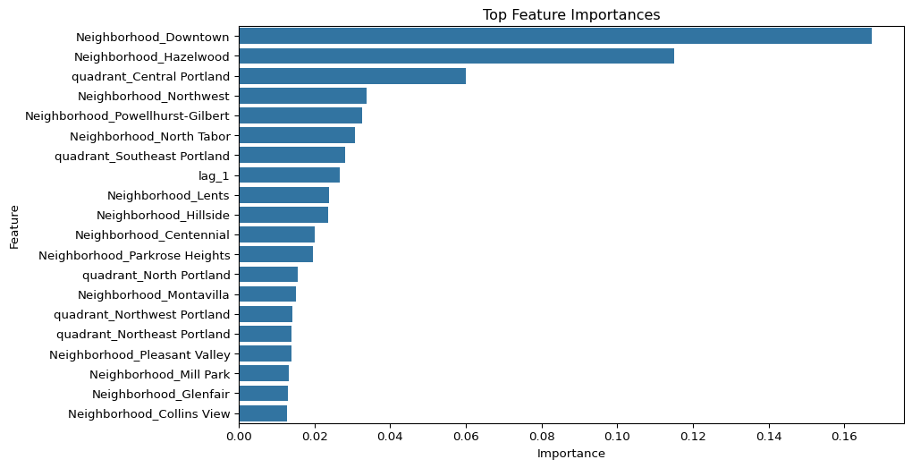

```python
import plotly.express as px
import matplotlib.pyplot as plt
import seaborn as sns

# Assuming 'xgb' is your trained XGBRegressor model and 'X' is your feature dataframe
feature_importances = pd.DataFrame({'Feature': X.columns, 'Importance': xgb.feature_importances_})
feature_importances = feature_importances.sort_values(by='Importance', ascending=False).head(20)

# Create a bar chart
plt.figure(figsize=(10, 6))
sns.barplot(x='Importance', y='Feature', data=feature_importances)  # Top 15 features
plt.title('Top Feature Importances')
plt.xlabel('Importance')
plt.ylabel('Feature')
plt.show()
```

### Current Final Observations

Right now, the model has an R² score of 0.62, meaning it can explain about 62% of the variation in daily crime counts. This is a solid result, especially for real-world human behavior. Still, there’s room to improve. Adding more information about each neighborhood—like population, income, education levels, and unemployment—could give the model a better understanding of what makes each area unique. This extra context could help the model make even more accurate predictions.

Back to top